# Projet ADM - MIASHS

Seydou NIARE, Darren SAMRETH

## I.Préparation des données et enrichissement

### 1. Importation des libraries

```r
library(FactoMineR)
library(factoextra)
library(tidyr)
library(pls)
library(MASS)
library(scales)
```

### 2. Importation des données

Les fichiers CSV du dossier data sont tous importés dans un dataframe nommé df.

Deux autres dataframe sont crées pour répartir les données train et les données test.

Les dates et les modalités sans valeurs sont supprimées, ainsi que les lignes qui contiennent des données manquantes.

```r
files = list.files(path = "data/", pattern="*.csv")
for (i in 1:length(files)){
  files[i] = paste("data/",files[i],sep="")
}
df = do.call(rbind, lapply(files, function(x) read.csv2(x, sep = ";", stringsAsFactors = F)))
files = list.files(path = "data/", pattern="*-train.csv")
for (i in 1:length(files)){
  files[i] = paste("data/",files[i],sep="")
}
df_train = do.call(rbind, lapply(files, function(x) read.csv2(x, sep = ";", stringsAsFactors = F)))
files = list.files(path = "data/", pattern="*-test.csv")
for (i in 1:length(files)){
  files[i] = paste("data/",files[i],sep="")
}
df_test = do.call(rbind, lapply(files, function(x) read.csv2(x, sep = ";", stringsAsFactors = F)))
df = na.exclude(df[,1:29])[,3:29]
df_train = na.exclude(df_train[,1:29])[,3:29]
df_test = na.exclude(df_test[,1:29])[,3:29]
```

## II. Analyse descriptive par ACP

Commençons par effectuer une ACP en utilisant toutes les données quantitatives à notre disposition. Nous travaillons avec des données standardisées afin de prévenir tout problème d’unité de mesure.

```r
res_pca <- PCA(df, scale.unit = T, graph=F)
```

**Commençons par déterminer un nombre pertinant de composantes à retenir.**

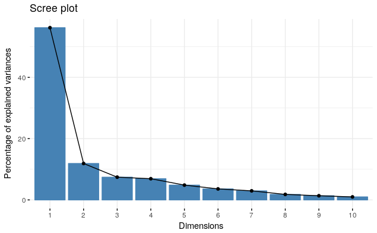

```r
fviz_screeplot(res_pca, ncp=10)
```

Deux composantes semble être suffisant, étant donné que l’ajout d’une troisième dimension ne semble pas ajouter une valeur-ajoutée assez conséquente pour être indispensable.

**Vérifions la contribution de chaque dimenension par rapport aux variables.**

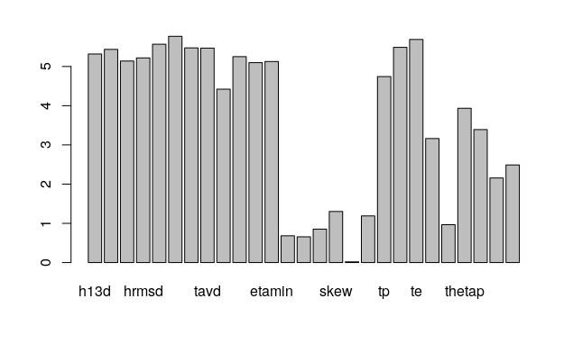

```r
barplot(res_pca$var$contrib[,1])
```

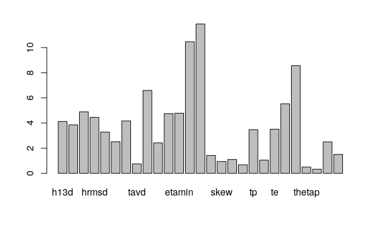

```r
barplot(res_pca$var$contrib[,2])
```

En étudiant les corrélations apportées par chaque dimension, on s’aperçoit que la première explique une grande partie des données. Les deux autres ne font qu’apporter plus d’information sur deux variables non corrélées dans la première dimension.

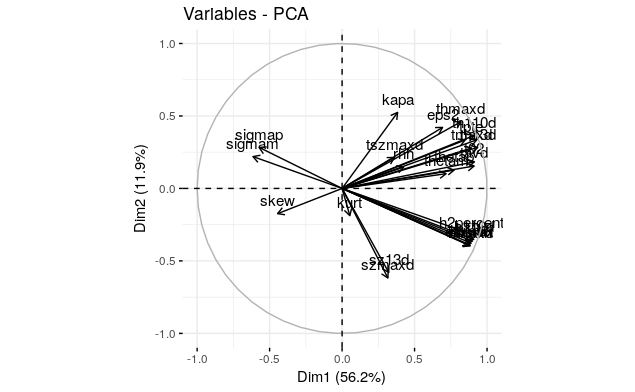

```r
fviz_pca_var(res_pca, axes=c(1,2))
```

Ce graphe des variables confirme qu’une grande majorité des variables sont bien représentés par les deux dimensions.

On peut déjà remarquer que trois variables (sigmap, sigmam et skew) sont inversement corrélées avec la plupart des autres variables sur l’axe de la première dimension.

**Etudions maitenant les individus :**

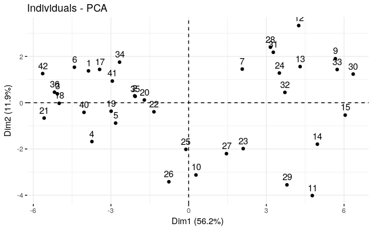

```r
fviz_pca_ind(res_pca)
```

Un groupe d’individu semble former une aggrégation dans les valeurs négative de la dimension 1, alors que les individus des valeurs positives semblent plus dispersés.

## III. Modélisation de la prédiction de h13d par modèles linéaires (classique, pcr et pls)

Tout d’abord, projetons les données d’apprentisage et de test sur les axes de l’ACP.

```r
res_pca = PCA(df_train, scale.unit = T, graph = F)
train_proj = res_pca$ind$coord
test_proj = t(apply(df_test, MARGIN = 1, FUN = function(x) { (x - res_pca$call$centre)/res_pca$call$ecart.type} )) %*% res_pca$svd$V
train_proj <- as.data.frame(train_proj)
test_proj <- as.data.frame(test_proj)
test_proj$h13d <- df_test$h13d
train_proj$h13d <- df_train[1:25,]$h13d
colnames(test_proj) <- colnames(train_proj)
```

**Maintenant, comparons différents trois modèles issus de méthodes différentes.**

### 1. Régression classique

```r
reg = lm(h13d~.,data = df_train)
summary(reg)
```

[output not shown]

La régréssion classique ne peut pas fonctionner, car il y a plus de régresseurs que de données dans le jeu d’apprentisssage.

Nous pourrions supprimer des régresseurs (au moins trois pour pouvoir effectuer la régression), mais nous choisissons plutôt de **travailler directement sur les composantes.**

### 2. Régression sur Composantes Principales

Nous utilisons les données projetées précedemment, et nous effectuons une régression en uilisant les composantes.

```r
model_pcr <- lm(h13d ~ ., data = train_proj)
step(model_pcr, direction = "both")
```

```
Start:  AIC=-100.53
h13d ~ Dim.1 + Dim.2 + Dim.3 + Dim.4 + Dim.5

        Df Sum of Sq     RSS      AIC
<none>                0.2774 -100.533
- Dim.3  1    0.0327  0.3101  -99.746
- Dim.4  1    0.2496  0.5269  -86.489
- Dim.5  1    0.3268  0.6042  -83.070
- Dim.2  1    0.7631  1.0405  -69.480
- Dim.1  1   10.7472 11.0246  -10.469

Call:
lm(formula = h13d ~ Dim.1 + Dim.2 + Dim.3 + Dim.4 + Dim.5, data = train_proj)

Coefficients:
(Intercept)        Dim.1        Dim.2        Dim.3        Dim.4        Dim.5
    1.02400      0.16301     -0.09966      0.02374      0.08249     -0.10901
```

```r
summary(model_pcr)
```

```
Call:
lm(formula = h13d ~ ., data = train_proj)

Residuals:
     Min       1Q   Median       3Q      Max
-0.14183 -0.08084 -0.02584  0.07437  0.27959

Coefficients:
             Estimate Std. Error t value Pr(>|t|)
(Intercept)  1.024000   0.024164  42.377  < 2e-16 ***
Dim.1        0.163009   0.006008  27.134  < 2e-16 ***
Dim.2       -0.099657   0.013783  -7.230 7.28e-07 ***
Dim.3        0.023737   0.015857   1.497 0.150819
Dim.4        0.082494   0.019950   4.135 0.000563 ***
Dim.5       -0.109010   0.023039  -4.732 0.000145 ***
---
Signif. codes:  0 ‘***’ 0.001 ‘**’ 0.01 ‘*’ 0.05 ‘.’ 0.1 ‘ ’ 1

Residual standard error: 0.1208 on 19 degrees of freedom
Multiple R-squared:  0.9776,    Adjusted R-squared:  0.9717
F-statistic:   166 on 5 and 19 DF,  p-value: 5.398e-15
```

```r
predict_pcr <- predict(model_pcr, test_proj)
rmse <- sqrt(mean((model_pcr$residuals)^2))
cat('RMSE :',rmse)
```

```
RMSE : 0.1053287
```

**Comparons ce modèle avec la méthode Partial Least Square Regression.**

### 3. Partial Least Square Regression

```r
plsr_fit <- plsr(h13d ~ ., data = df_train)
summary(plsr_fit)
```

```
Data:   X dimension: 25 26
    Y dimension: 25 1
Fit method: kernelpls
Number of components considered: 24
TRAINING: % variance explained
      1 comps  2 comps  3 comps  4 comps  5 comps  6 comps  7 comps  8 comps  9 comps
X       97.98    99.46    99.63    99.95    99.97    99.99    99.99   100.00   100.00
h13d    48.65    61.23    72.19    75.12    98.54    98.87    99.19    99.45    99.66
      10 comps  11 comps  12 comps  13 comps  14 comps  15 comps  16 comps  17 comps
X       100.00    100.00    100.00    100.00    100.00    100.00    100.00       100
h13d     99.81     99.89     99.93     99.96     99.98     99.98     99.99       100
      18 comps  19 comps  20 comps  21 comps  22 comps  23 comps  24 comps
X          100       100       100       100       100       100       100
h13d       100       100       100       100       100       100       100
```

La variance expliquée atteint assez rapidement les 98 % pour cinq composants. Cela doit être un nombre de componsant intéressant.

**Etudions maintenant l’évolution du RMSEP (Root Mean Square Error of Prediction).**

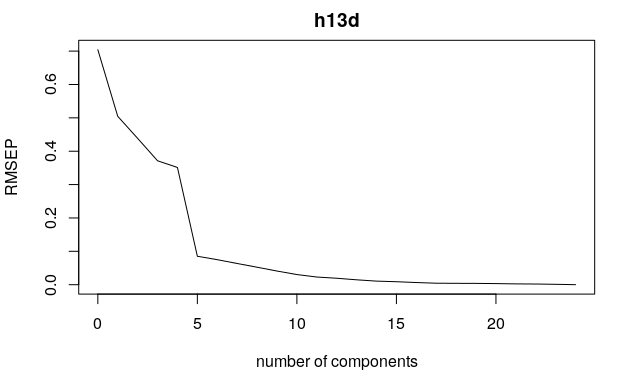

```r
plot(RMSEP(plsr_fit))
```

Le choix des cinq composants semble encore être une bonne solution, car il correspond au moment où l’évolution du RMSEP se stabilise. Le modèle est donc quasiment à sa précision optimale. Nous utiliserons donc cinq composants.

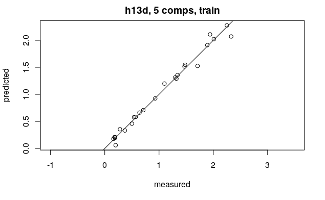

```r
plot(plsr_fit, ncomp = 5, asp = 1, line = T)
```

** Vérifions maitenant si notre modèle est bon en le testant sur nos données de test.**

```r
pred <- predict(plsr_fit, ncomp = 5, newdata = df_test)
rmse <- sqrt(mean((pred - df_test$h13d)^2))
cat('RMSE :',rmse)
```

```
RMSE : 0.310889
```

## IV. Classification et prédiction des classes d’individus

Construisons une classe “type de vague”, qui caractérise les grandes, les moyennes et le petites vagues.

```r
df_train$vague <- with(df, ifelse(
  df_train$h13d > 2, 'grande', ifelse(
  df_train$h13d >= 1, 'moyenne','petite')))
df_test$vague <- with(df, ifelse(
  df_test$h13d > 2, 'grande', ifelse(
  df_test$h13d >= 1, 'moyenne','petite')))
```

Maintenant construisons notre classificateur. Il nous permettra de déterminer le type de vague, si nous n’avons accès à aucune information sur la hauteur de la vague.

[figure not shown]

```r
lda_fit <- lda(vague ~., data =df_train[6:28])
plda <- predict(object = lda_fit, newdata = df_train)
prop_lda = lda_fit$svd^2 / sum(lda_fit$svd)
dataset = data.frame(vague = df_train[,"vague"], lda = plda$x)
# plot
library(scales)
p1 <- ggplot(dataset) + geom_point(aes(lda.LD1, lda.LD2, colour = vague, shape = vague), size = 2.5) +
  labs(x = paste("LD1 (", percent(prop_lda[1]), ")", sep=""),
       y = paste("LD2 (", percent(prop_lda[2]), ")", sep="")) +
  theme_bw() +
  labs(title = "LDA", subtitle = "dataset")
p1
```

**Vérifions l’efficacité de notre classificateur.**

```r
pred <- predict(lda_fit, df_test)
cat("Fréquence de bon résultat : ",mean(pred$class == df_test$vague))
```

```
Fréquence de bon résultat :  0.6666667
```

## V Utilisation de la classification hiérarchique (bonus)

**FactorMineR::HCPC par defaut:

HCPC proposer 3 cluster pour notre composant principal on a:

```r
  hc<-FactoMineR::HCPC(res_pca,nb.clust = 3)
```

[output not shown]